# Category widths capture fixed log-stimulus ratios in video game reviews, historical stellar catalogs, and word familiarity judgments

- Show All Code
- Hide All Code
- View Source

Or, why the psychophysical law is a stretched exponential function

Author

Vlad Chituc

Published

August 23, 2026

**ImportantAI-assembled — not for publication**

This page was assembled by an AI agent from the outputs of the registered analysis scripts in `ign-ratings/scripts/` (see `scripts/REGISTRY.md`). Prose has not been line-by-line verified by a human; do not publish or cite as-is. All statistics are read directly from the scripts’ `processed_data/` outputs, not recomputed here.

## Overview

This page collects one set of analyses run identically across three very different rating systems:

1. **IGN video game ratings** (integer 1–10, 2020–2025) against Steam outcome data — a purely **subjective, evaluative categorization**: game quality has no discernible objective correlate (no retinal neurons registering photons, not even an implicit tally of exposures — just an aesthetic/hedonic evaluation), yet that evaluation has real-world correlates we can measure, player counts and sales;
2. **historical stellar magnitudes** (brightness classes 1–6, assigned by 14 observers from Ptolemy in 137 AD to Piazzi in 1814) against modern photometric flux — an **objective perceptual categorization**: a physical magnitude arriving at the eye, categorized by scientists *as a measurement* of that magnitude; and
3. **word familiarity norms** (Glasgow Norms, 1–7 scale) against corpus word frequency — an **experiential categorization of an objective quantity**: how often you encounter a word is an objective count, but nothing perceives it directly — the judgment reads accumulated experience out of memory.

The test is in that sense fully general: the same battery runs on a perceptual categorization of a physical magnitude, a memory-based categorization of an objective exposure count, and a pure aesthetic evaluation with no objective correlate at all — three different kinds of judgment, three unrelated corners of the space of things a rating scale can do. Finding the same spacing law in all three would otherwise be what Meehl (1990), borrowing Wesley Salmon’s (1984) phrase, called a **damn strange coincidence**: theories earn credence by predicting facts that, absent the theory, would be antecedently improbable — and the agreement below is exactly that kind of fact.

One disambiguation, used strictly throughout: the IGN data come from video game *reviews*, and the sales proxy is the count of Steam user *reviews* — two different things that share a word. On this page, **rating** always refers to the IGN 1–10 score, and **reviews** always refers to the Steam review count (the sales proxy).

The same basic pattern appears in all three. Throughout, the objective quantity paired with each rating — review counts, player counts, photometric flux, corpus frequency — is called the **stimulus**: the magnitude the score is treated as categorizing. When an ordinal rating scale is treated as a categorization of the stimulus measured in **log-stimulus space**, the category boundaries are not equally spaced. Instead each successive category is *wider* than the one below it by a roughly constant multiplicative factor — a **geometric progression of category widths**, with ratio r ≈ 1.24–1.27 for IGN ratings, r ≈ 1.17 for stellar magnitudes (1.16 with a pre/post-telescope era control; Section 6.6), and r ≈ 1.41 for word familiarity. Note what is and isn’t constant: the raw stimulus ratio per step is *not* constant (that would be a logarithmic scale) — it is the step size *in log-stimulus coordinates* that grows by the constant ratio r, so the raw per-step stimulus ratios themselves compound.

An equivalent description on the category means:

$$\log \Phi = c + A\,e^{\beta S},$$

where **Φ** is the stimulus (reviews, players, flux, corpus frequency), **S** is the rating, **c** is an additive floor (the log-stimulus level the scale bottoms out at), **A** is a scale constant, and **β** is the growth rate — the log of the width ratio r, so β = ln r. In terms of the rating this says log-stimulus *compounds*: each rating step multiplies (log Φ − c) by e^β = r. Under the reading S = k·log ψ (ψ the latent magnitude) the same equation becomes log Φ = c + A′·ψ^(βk) with βk < 1 — the **stretched exponential** in ψ from which this page takes its name. One line to keep the fitted and the inferred separate: what is *literally fit* to data, everywhere on this page, is the S-space form — fixed log-stimulus ratios — and the analyses **test the SE law** through that observable signature; the final step from the S-form to a stretched exponential in ψ is inferred through S = k·log ψ, not fit. In every dataset the fixed-log-stimulus-ratio mean function beats the fixed-stimulus- ratio (Fechnerian) alternative, and a power law in the raw stimulus loses badly. Section 2 derives the form from first principles, introduces the function properly, and says where it sits in the history of psychophysics.

**Read headline numbers from processed_data**

```r
library(dplyr); library(jsonlite); library(knitr); library(ggplot2); library(tidyr)
pd <- "../processed_data"
r16 <- read_json(file.path(pd, "16_results.json"))
r73 <- read_json(file.path(pd, "73_results.json"))
r71 <- read_json(file.path(pd, "71_results.json"))
n58 <- read.csv(file.path(pd, "58_norms.csv"))[1, ]

tibble::tribble(
  ~Dataset, ~Rating, ~`Stimulus (log)`, ~n, ~`Geometric ratio r`,
  "IGN × peak concurrent players", "IGN 5–10 (integer era)", "log all-time peak concurrent players",
    r73$n, round(r73$geometric_r, 3),
  "IGN × Steam reviews", "IGN 5–10", "log Steam total reviews",
    r16$steam$n, round(r16$steam$geom_r, 3),
  "IGN console-inclusive", "IGN 5–10", "log Metacritic user-rating count",
    r16$full$n, round(r16$full$geom_r, 3),
  "Stellar magnitudes", "brightness class 1–6", "log relative flux (Hipparcos V)",
    r71$preera$battery$n, round(r71$preera$battery$thresholds$pooled$geom$r, 3),
  "Word familiarity", "Glasgow FAM 1–7 (rounded item means)", "SUBTLEX-UK Zipf frequency",
    n58$n, round(n58$r_geom, 3)
) |> kable()
```

| Dataset | Rating | Stimulus (log) | n | Geometric ratio r |
| --- | --- | --- | --- | --- |
| IGN × peak concurrent players | IGN 5–10 (integer era) | log all-time peak concurrent players | 508 | 1.244 |
| IGN × Steam reviews | IGN 5–10 | log Steam total reviews | 560 | 1.269 |
| IGN console-inclusive | IGN 5–10 | log Metacritic user-rating count | 803 | 1.234 |
| Stellar magnitudes | brightness class 1–6 | log relative flux (Hipparcos V) | 8446 | 1.173 |
| Word familiarity | Glasgow FAM 1–7 (rounded item means) | SUBTLEX-UK Zipf frequency | 4677 | 1.409 |

Table 1: Headline geometric ratios: the estimated common ratio r of successive category widths, per battery.

Here **r** is the estimated common ratio of successive category widths, read from the threshold spacing of a graded response model anchored to log stimulus (the GRM — the standard psychometric model for ordered categories; Section 5 is the supplement that explains it); r = 1 would mean equally spaced categories in log stimulus (“Fechnerian” spacing — fixed *stimulus* ratios per category), r > 1 means categories widen going up the scale (fixed *log-stimulus* ratios, per the title).

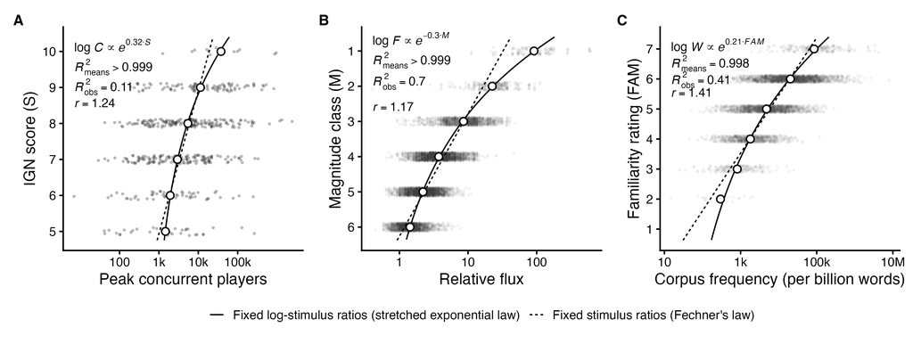

Figure 1: The three main results in one figure: (A) IGN ratings 5–10 × all-time peak concurrent players, (B) historical stellar magnitude classes × modern flux (the pre-telescope-sky sample of Section 6), and (C) Glasgow word-familiarity ratings × SUBTLEX-UK corpus frequency. Gray dots = individual games / class assignments / words; open circles = category geometric means; solid = fixed log-stimulus ratios (the stretched-exponential law’s observable form); dashed = fixed stimulus ratios (Fechner’s law). Each panel reports its fitted equation, R² over category means and over individual observations, and its geometric width ratio r. Generated by script 23 (main variant).

The stellar sample is restricted to the pre-telescope sky — telescopic-era observers enter only on stars a pre-telescopic catalog contains (Section 6); a pre/post-telescope era control barely moves its r (Section 6.6).

**Reproducibility.** Every number on this page is read from `processed_data/` files written by the numbered, registered scripts in `scripts/` (index: `scripts/REGISTRY.md`; seed 42 throughout). The page performs **no new analysis**: it loads result JSONs and CSVs and displays them. Figures are the scripts’ own PNG outputs (script number in each caption) or simple plots of per-category summary tables.

## Where the stretched exponential comes from

### Two dueling psychophysical laws

In the history of psychophysics there are two dueling candidates for the **psychophysical law** — the function governing the relationship between the physical world (a physical stimulus like the objective number of photons hitting your eye — the Φ of the equation above) and the mind (a psychological magnitude like the intensity of a perceptual experience — in this example subjective brightness; the ψ).

**Fechner** (1860) proposed a logarithmic law, ψ = log Φ: each *ratio* change of the stimulus (say, a doubling) produces a constant *additive* change in psychological magnitude. He proposed measuring psychological magnitude by **summing** units of just-noticeable differences (JNDs) in the stimulus — because the JND captures stimulus ratios. Consider the difference between a 2-inch line and a 3-inch line: to reproduce that same subjective difference at a larger size, you need to put a 30-inch line next to the 20-inch one (50% bigger), not a 21-inch line (1 inch longer). Stimuli must differ by a constant *ratio* to be equally discriminable — the constant is the **Weber fraction**, and the general principle is **Weber’s law**. (There is a good case that Weber’s law is a property of *physics*, not perception — measurement error in general behaves this way, and for naturally fluctuating intensities constant relative error is what an optimal receiver of any kind achieves: Pednekar, Krishnadas, Cho & Makris 2023, *Proc. R. Soc. A* 479:20220626.)

Modern psychometrics implicitly inherits Fechner’s identification. Thurstone (1927) was explicit about it: his law of comparative judgment builds the psychological scale out of confusability, with the **discriminal dispersion** — the standard deviation of the momentary judgment process — as the unit of the continuum, so that equal scale distances just *are* equal discriminability. Luce and Edwards (1958) showed how that summation must be done to be internally consistent — and that it yields a logarithmic scale only if Weber’s law holds exactly — while insisting that equal JNDs are a convention, not a discovery about felt magnitude. And the same move defines the modern latent-trait scales: a Rasch or IRT θ is measured in units of response noise (a logit or probit step is one standard-deviation-of-judgment’s worth of endorsement probability), as is signal detection’s d′ (distance in noise-SD units). Any scale whose unit is variance — wherever noise is what gets summed to produce the psychological continuum — is a JND-count scale, and so silently assumes Fechner’s identification of experience with discrimination units, rather than asking, with Stevens, how felt magnitude grows *across* those units.

**Stevens** (1957) proposed a power law instead: ψ = Φ^a, the subjective intensity is the stimulus raised to a power. The exponent a is usually read off a log-log plot, where log ψ = a·log Φ is a straight line with slope a. A power law means equal *ratio* changes of the stimulus produce equal *ratio* changes of the psychological magnitude. That is perceptually useful, because ratios out in the world are what matter: if one stick is twice as long as another, it *appears* twice as long whether it is right in front of you or twenty yards away.

Stevens’ law collected its own embarrassments, though. Measured exponents refuse to behave like constants of nature: they drift with stimulus range, context, and procedure (Poulton 1968; Teghtsoonian 1973), and Shepard (1981) argued that direct scaling cannot, by itself, uniquely pin down the psychophysical function at all: a magnitude estimate is the composition of two mappings — stimulus into sensation, and sensation into the emitted number — and the judgments constrain only the composition, so any candidate ψ can be traded away against a compensating response function. And the law’s core virtue overreaches: strict scale invariance says perception preserves ratios and *nothing else* — no trace of absolute scale — when in fact we live in, and perceive, a world that is only approximately scale invariant. Hold both embarrassments; the stretched exponential answers them below.

### What rating scales do: the psychometric law

Alongside the psychophysical law (world → mind, Φ → ψ), it is useful to name a second mapping: call the function from mind to *measurement* — from ψ to the reported score S — the **psychometric law** (my term; it is not an established one). My empirical work finds that this psychometric law is a **logarithmic function of ψ** — S = k·log ψ + const, with k the scale’s slope (Chituc & Santos, under review). Across pain, crime severity, and eight further subjective experiences (happiness, morality, beauty, desires, opinions, love, fear), subjects rated self-generated exemplars on both a standard 10-point self-report scale and a magnitude estimation scale: the self-report ratings are a near-perfect logarithmic compression of the magnitude estimates (median R² = .99), with each scale step worth a median ratio of ×1.9 (IQR [1.8, 2.0]) of underlying magnitude. Rating scales, in other words, work like decibels or earthquake magnitudes — they capture equal *ratios* of the thing they measure, and one scale point does roughly what 10 decibels does for perceived loudness (about a doubling — of the subjective magnitude, not the physical energy). The compression is drastic enough that the subjective midpoint of a 10-point scale sits near its top: the last point captures nearly as much subjective distance as the first nine combined. And the same work shows this is a fact about the *report scale*, not the judgments: magnitude estimates preserve additivity (sums of ratings track sums of experiences; completion-task slopes ≈ 1) and midpoint structure (bisection-task slopes ≈ 1), while self-report ratings are compressed on both.

This makes a rating scale something like the y-axis of Stevens’ log-log plot: if S is in effect log ψ, and Stevens is right that ψ = Φ^a, then S = a·log Φ + const. (One caveat: this route cannot recover a good estimate of a, because we do not know the base of the logarithm the psychological scale uses — a log-log slope is only exact when both axes use the same base; otherwise a is off by a multiplicative constant. None of that matters for anything here.) But note what that composition predicts: ratings *linear in log stimulus* — equal category widths in log-stimulus space. That is exactly the Fechnerian threshold model that loses in every dataset on this page.

### A third law: a stretched exponential function

I have grown increasingly convinced that the psychophysical law is neither Fechner’s logarithm nor Stevens’ power law of the stimulus, but a third thing: Fechner was right that the fundamental unit is the JND, and Stevens was right about the functional form. Suppose perception follows a power law not of the stimulus per se but of the stimulus’s **discriminability** — the number of JNDs it sits above threshold, which by Weber’s law is a logarithmic function of the stimulus: n = log(Φ/Φ₀), with Φ₀ the threshold. Then

$$\psi = n^{\gamma} = \big(\log (\Phi/\Phi_0)\big)^{\gamma},$$

where **n** is the JND count, **γ** is the power-law exponent on it, and **Φ₀** is the perceptual threshold.

One disambiguation before composing, because “JND” is doing partly metaphorical work here. A JND is a *behavioral* object — a discriminability judgment — and the claim is not that sensory transduction literally consumes discriminability judgments as inputs. The substantive claim is about the front end’s *coordinates*: a receiver that minimizes relative error has constant resolution in log-stimulus units, so its input arrives naturally denominated in resolvable steps — a quantity that counts stimulus ratios exactly as summed JNDs would. “JND count” is the convenient name for that coordinate because Fechner made it famous and because behavioral JNDs are how it was historically measured, but the law needs only the logarithmic input coordinate, not the psychophysics of discrimination itself. One consequence worth keeping in mind: the well-documented deviations in discrimination experiments — the near-misses to Weber’s law, for instance — are facts about discrimination *judgments*, and whether they propagate into this input coordinate is an open question, not an assumption of the account.

Compose this with the psychometric law S = k·log ψ + const and the rating becomes a log of the JND count:

$$S = k\gamma \cdot \log\big(\log (\Phi/\Phi_0)\big) + b,$$

with **b** collecting the constants. The world gets logged *twice* on its way to the scale — once by Weber (stimulus → discriminability units), once by the report scale (magnitude → category number). Solving for the stimulus given the rating — which is the direction the data on this page are fit in — gives

$$\log \Phi = c + A\,e^{\beta S}, \qquad c = \log \Phi_0, \quad \beta = \tfrac{1}{k\gamma},$$

exactly the mean function fitted throughout this page. Because the scale is a log of a log of the stimulus, going back from scale to world simply undoes the two logarithms — that is all the equation is. It packs several moves into one line, so here is the same equation read piece by piece, from the rating out to the stimulus:

- **Start with the rating S** and scale it by β. Because β = 1/(kγ), this one constant undoes both stages of the mind’s compression at once: k (how many scale points the report scale assigns per ratio step of ψ) and γ (the power law relating ψ to the JND count). A small β means a lot of compression happened on the way in.
- **Exponentiate: e^(βS).** This undoes the outer logarithm — the report scale’s. The result, scaled by A, is the **JND count**: n = A·e^(βS), the number of just-noticeable steps the stimulus sits above threshold. Note what the exponential does per rating point: each +1 in S multiplies the JND count by e^β — a constant factor. This is exactly where the geometric widths come from, r = e^β.
- **A is the anchor**: at S = 0 the formula gives n = A, so A is the JND count where the scale’s zero sits — how far up the discriminability ladder the bottom of the scale is.
- **Add c = log Φ₀.** The JND count is a count of *ratio* steps of stimulus (Weber), so it lives in log-stimulus units; to turn it into an absolute log-stimulus position you add the threshold, the stimulus level at zero JNDs. Below Φ₀ nothing is detectable, which is why the floor is not optional.
- **Read off log Φ = c + A·e^(βS)**: log stimulus = threshold + JND count. The whole law in one sentence: *the rating indexes the JND count geometrically, and the JND count sits on top of the threshold in log-stimulus space.*

This double-log structure is also exactly where the **fixed log-stimulus ratios** come from. A unit step of the rating *adds* a constant (β) two logs up — on log(log Φ − c). Adding a constant to a logarithm means *multiplying* the quantity underneath it: so one log up, the floored log-stimulus (log Φ − c) is multiplied by e^β = r with every step — the geometric category widths. And multiplying a logarithm means *raising to a power* underneath it: at ground level, each step raises the stimulus span above threshold to the power r. One constant, read at three depths of the ladder — additive at the top, multiplicative in the middle, a power at the bottom.

Substituting S = k·log ψ back in gives log Φ = c + A′·ψ^(βk) with βk < 1 — log-stimulus as a decelerating **power law** of the latent magnitude, every parameter now carrying a psychophysical meaning.

And to put this back in the original psychological frame, with the report scale gone entirely: the substitution turns e^(βS) into ψ^(βk) (the exponential of a logarithm is a power), so the rating S drops out and what remains is a relation between world and mind alone —

$$\Phi = \Phi_0 \, e^{A'\,\psi^{1/\gamma}},$$

or, in log form (removing the double exponent),

$$\log(\Phi/\Phi_0) = A'\,\psi^{1/\gamma}:$$

**the world is a stretched exponential of the mind.** This is the function the page is named for, so it deserves a proper introduction. A **stretched exponential** is an exponential whose argument has been compressed by a power less than one — y = e<sup>(A·x</sup>b) with 0 < b < 1; here x = ψ and b = 1/γ. At b = 1 it is an ordinary exponential; with b < 1 the growth is “stretched” over a much wider range, with no single characteristic scale. One logarithm removes the exponential and leaves a pure power law (that is the second display above); a second log straightens it into a line with slope b. The name comes from physics: the decaying version, f(t) = e<sup>(−(t/τ)</sup>b), is Kohlrausch’s (1854) relaxation law for disordered materials, and the family has had a modern revival as the disciplined alternative to power laws for heavy-tailed phenomena. Laherrère and Sornette (1998) showed that with just two interpretable parameters it describes the luminosities of galaxies, oilfield reserve sizes, urban agglomerations, country populations, daily currency fluctuations, the 400,000-year Vostok temperature record, the fossil extinction kill curve, earthquake sizes, and citation counts — and that it arises generically wherever a quantity is the product of finitely many random factors, the exponent b tracking the length of the multiplicative chain. Figure 2 shows the family in the increasing form used on this page.

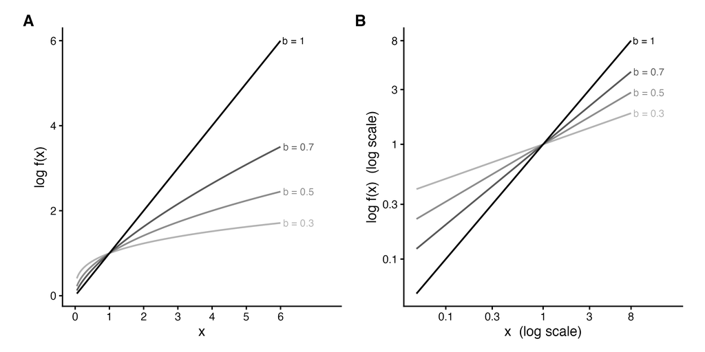

Figure 2: The stretched-exponential family in its increasing form, f(x) = e<sup>(x</sup>b): (A) log f(x) against x — the ordinary exponential (b = 1) is a straight line and the stretched members (b < 1) bend over, the same decelerating bend the solid fits trace through the data panels above; (B) both axes logged — the second log straightens every member into a line with slope b. Generated by script 75.

This is also where Stevens’ two embarrassments dissolve. Under the stretched-exponential law the local Stevens exponent is not a constant: it is γ divided by the number of e-folds the stimulus sits above threshold (d log ψ / d log Φ = γ / log(Φ/Φ₀)) — so measured exponents *should* drift with range and level, exactly as Poulton and Teghtsoonian found. Yet the law still delivers what made the power law attractive, over the range where it matters: for a stimulus sitting n e-folds above threshold, the exponent is nearly constant across any span of δ e-folds with drift only of order δ/n. Far above threshold — where ecologically typical stimuli live, many e-folds up — ratio structure is preserved locally: the stick that is twice as long still looks twice as long. Near threshold, and across very wide ranges, the exponent bends lawfully — and that slow bend is not a bug but the signature of **characteristic scale**, the absolute-position information a strict power law would erase. A power law is tuned to a perfectly scale-invariant world; the stretched exponential is tuned to ours, which is only approximately so.

Shepard’s indeterminacy, meanwhile, is answered by how these analyses are built rather than by the law itself. Nothing on this page treats the reported number as a readout of ψ: the rating enters only as an *ordinal* category, and every empirical claim lives on the stimulus side — where the boundaries sit in log-stimulus space — a structure untouched by any monotone relabeling of the response scale, which is exactly the degree of freedom Shepard showed direct scaling cannot fix. The decomposition into psychophysical and psychometric halves is then constrained by *independent* evidence for the psychometric half (report scales log the mind), not by the scaling data being decomposed — and the one degree of freedom that genuinely remains, the log base k, is flagged as unidentified throughout rather than silently fixed.

Two remarks about the form as it appears here. **Naming**: the fitted S-form, log Φ = c + A·e^(βS), is an ordinary exponential in the rating; the relation is a stretched exponential specifically *in ψ*, because S = k·log ψ turns e^(βS) into the compressed power ψ^(βk) — an exponential of a logged variable just *is* a power law of the underlying one. Calling the mean function “stretched-exponential” throughout this page is shorthand licensed by that psychometric reading. **Direction**: read the other way, the same curve is the power-of-log law, ψ ∝ (log Φ/Φ₀)^γ — and nothing psychological hangs on which direction wears the logarithm. Inverting swaps the two forms (a stretched exponential undone is a power of a log), and the log of Φ is just the world re-expressed in its natural ratio coordinates — by Weber’s law only stimulus *ratios* carry information, so Φ’s unit, and with it the log’s base, is pure convention. One curve, two readings. So the psychophysical law that reconciles Fechner and Stevens — and with them reintegrates psychophysical scaling and the psychometric tradition that pulled apart from it about a century ago — can fairly be called a **stretched exponential law**. Note only that this reverses the classic direction in which the law is framed: psychophysics traditionally writes the law running from the world to the mind (ψ = f(Φ)), whereas the stretched-exponential form runs from the mind to the world (Φ = f(ψ)).

Equal unit changes of the rating should therefore produce equal *ratio* steps of the (floored) log stimulus — geometric category widths, with r = e^β. And the two rivals fall out of the same algebra as the two ways to break the chain: keep Fechner all the way (γ = 1) and log Φ is linear in S — flat step ratios; keep Stevens on the raw stimulus (skip the Weber log) and the step ratios *decelerate*. Only the double-log chain produces the accelerating ratios the data show (×1.32 → ×3.33 on peak players; ×1.35 → ×4.07 on reviews). That is what video game ratings, stellar magnitudes, and word familiarity all do — which presents a parsimonious reconciliation: **the unit (the JND) goes to Fechner, and the form (the power law) goes to Stevens.** Stated as errors: Fechner’s mistake was not where he put the logarithm but that he had only one log and asserted γ = 1 — identifying experience with the JND count itself, each detection step one equal unit of feeling (an identification the psychometric tradition inherited). Stevens’ mistake is the mirror image: right functional form, wrong argument. The mind does not take the raw stimulus as its input — no percept has access to photons-per-second as such. It takes the *detected* stimulus: what survives the sensory front end. And if that front end is an optimal receiver minimizing *relative* error — which is what Weber’s law amounts to, for the eye as for any well-designed instrument (Pednekar et al. 2023) — then the input to the psychophysical law arrives already denominated in discriminability: JND counts, in which equal steps are equal increments of resolvable evidence. Stevens applied his ratio-preserving power law to the physicist’s Φ, when the quantity actually crossing the receiver’s front door was log(Φ/Φ₀). Let his own law preserve ratios of the *evidence* rather than ratios of the energy, and it lands exactly on the third law above. Each was right about one half; the law above is both halves assembled.

## The IGN dataset

### Provenance

I met Tom Marks — Associate Reviews Director at IGN, so maybe not *the* guy who runs the reviews, but at least one of *the* guys — playing Magic: The Gathering at my local game store. I got very interested in how thoughtful they are about assigning ratings to games. That is my bread and butter. So I started digging.

IGN switched to whole-number 1–10 ratings in January 2020 (“integer era”). Ratings here come from the published Kaggle scrape `davutb/metacritic-games` (Metacritic snapshot 2025-03-16) — **not** scraped from IGN directly (Ziff Davis robots.txt prohibits automated harvesting). Coverage is partial: roughly 165 IGN ratings per year captured vs the 250+ IGN publishes.

Two stimulus measures are carried through the IGN analyses. The **primary** measure is play behavior; the review count is the secondary, corroborating measure:

- **All-time peak concurrent players** (primary; script `06_fetch_more_outcomes.py`): the highest number of players ever simultaneously in the game, scraped per-game from SteamCharts — a third-party archive that logs Valve’s official concurrent-player telemetry — in the fetch of 2026-08-12 (coverage: 525 of the 607 matched games; n = 508 in the ratings-5–10 analyses). No review-writing enters this pipeline at any point.
- **Steam total review count** (secondary; script `03_fetch_steam_outcomes.py`): from the official Steam `appreviews` API — a census-complete, official count of all user reviews ever posted for the game. It serves as a sales proxy (unit sales are roughly 20–90× the review count per title, the “Boxleiter” multiplier; this is a proxy, not unit sales).

In the psychophysical framing used throughout this page, these measures play the role of the **stimulus** — the objective magnitude the rating is treated as categorizing. One caveat, and how it resolves: unlike flux hitting an astronomer’s eye, raters never perceive player counts or future sales. But they *are* perceiving game quality. If concurrent players and sales are a proxy for game quality — a decently plausible assumption; I wouldn’t lose sleep if it didn’t work, but the results below are hard to explain otherwise if it does, and it does — then the logic carries through unchanged, with the two independent proxies serving as checks on each other.

### Exclusion funnel

```r
funnel <- read_json(file.path(pd, "01_funnel.json"))
read.csv(file.path(pd, "05_exclusion_funnel.csv")) |>
  kable(col.names = c("Step", "n"))
```

| Step | n |
| --- | --- |
| unique IGN integer-era games | 841 |
| matched to Steam appid | 607 |
| steam type = game | 578 |
| has Steam review data | 578 |
| total_reviews >= 10 (analysis N) | 578 |

Table 2: Exclusion funnel from unique integer-era IGN games to the Steam-matched analysis sample (05_exclusion_funnel.csv).

From 13312 raw IGN critic rows, 851 unique integer-era ratings of 841 games survive (published 2020-02-03 to 2025-03-12). Unmatched games are mostly console/Epic/VR exclusives and DLC.

### Rating distribution, and why ratings 5 and up

[figure not shown]

Figure 3: IGN integer-era rating distribution (851 ratings; counts from 01_funnel.json), with IGN’s published verbal label for each rating.

```r
sd <- funnel$score_distribution_1to10
ign_labels <- c(`1` = "Unbearable", `2` = "Painful", `3` = "Awful", `4` = "Bad",
                `5` = "Mediocre", `6` = "Okay", `7` = "Good", `8` = "Great",
                `9` = "Amazing", `10` = "Masterpiece")
dist <- tibble::tibble(score = as.integer(names(sd)), n = unlist(sd)) |>
  mutate(lab = ign_labels[as.character(score)], inside = n >= 100)
ggplot(dist, aes(n, factor(score, levels = 1:10))) +
  geom_col(fill = "grey30", width = 0.7) +
  geom_text(aes(x = ifelse(inside, n - 4, n + 4), label = lab,
                hjust = ifelse(inside, 1, 0), color = inside), size = 3) +
  scale_color_manual(values = c(`TRUE` = "white", `FALSE` = "black"), guide = "none") +
  labs(x = "Ratings", y = "IGN rating") +
  theme_classic(base_size = 11)
```

Each number on the scale is a named **verbal category** — IGN publishes a label for every integer, from 1 (“Unbearable”) up through 5 (“Mediocre”), 7 (“Good”), and 10 (“Masterpiece”) — so the 1–10 rating is an ordered set of named categories, not a bare number line. The mode is 8 (“Great”); 73% of ratings are 7–9; no game received a 1, and ratings 2–4 are sparse (n = 7, 5, 25).

The analyses on this page use **ratings 5 (“Mediocre”) through 10 (“Masterpiece”) only**. Beyond the sparsity, the 1–10 scale is *bipolar*: the labels run from bad through neutral to good — the bottom half is explicitly negative (4 “Bad”, 3 “Awful”, 2 “Painful”, 1 “Unbearable”) — and we don’t want to mix constructs. The neutral-to-good half tracks how *good* a game is; the full bad-to-neutral-to-good range would also be tracking how *bad* it is — a different construct. Restricting to “Mediocre”-and-up keeps the analysis on a single (unipolar) construct. The 5–10 samples are: **n = 508** games on the primary measure (peak concurrent players), **N = 560** Steam-matched games on the review-count measure, and **N = 803** in the console-inclusive replication (all platforms, Metacritic user-rating count as the stimulus measure).

### Standing caveats

- **Proxy stimulus measures.** Peak concurrent players (the primary measure) confounds popularity with longevity, and Steam reviews are not unit sales (an independent calibration against developer-reported sales — script 18, GameDiscoverCo Oct-2022 survey, 199 games — gives log-units ~ log-reviews slope b = 1.087, R² = 0.925: reviews slightly *understate* the spread in sales).
- **Steam selection.** 234 console/Epic/VR-exclusive games are excluded from the Steam-matched sample; the console-inclusive replication (N = 803) is reported alongside throughout.
- **Correlational.** No causal claim; marketing budgets plausibly drive both ratings’ visibility and sales.
- **Coverage.** The Metacritic scrape misses roughly a third of IGN’s output.

## Rating → stimulus: the mean function

Per rating point, **both** stimulus measures — Steam reviews and peak concurrent players — multiply, but not by a constant factor. The step ratios **accelerate** going up the scale, which is what a stretched-exponential mean function predicts, and what a power law in the raw stimulus cannot produce: a power law predicts *decelerating* step ratios. Scripts: `05_analysis.R`, `07_functional_form.R`, `10_extended_outcomes.R`, `16_upper_scale.R`, `17_item_means_owners.R`, `19_four_panel.R`.

### Per-step geometric means, both measures

```r
fmt <- function(v) ifelse(is.na(v), "—", sprintf("%.2f", v))
steps <- read.csv(file.path(pd, "05_per_step_table.csv")) |>
  filter(ign_score_10 >= 5) |>
  mutate(ratio = geom_mean_reviews / lag(geom_mean_reviews),
         ror = ratio / lag(ratio))
ccu <- read.csv(file.path(pd, "10_per_step_extended.csv")) |>
  filter(ign_score_10 >= 5) |>
  mutate(ccu_ratio = geom_peak_ccu / lag(geom_peak_ccu),
         cror = ccu_ratio / lag(ccu_ratio))
left_join(steps, ccu, by = "ign_score_10") |>
  transmute(`IGN rating` = ign_score_10,
            `n` = n.y,
            `Geom. mean peak players` = round(geom_peak_ccu),
            `Ratio` = fmt(ccu_ratio),
            `Ratio ×` = fmt(cror),
            `n ` = n.x,
            `Geom. mean reviews` = round(geom_mean_reviews),
            `Ratio ` = fmt(ratio),
            `Ratio × ` = fmt(ror)) |>
  kable(align = "rrrrrrrrr")
```

| IGN rating | n | Geom. mean peak players | Ratio | Ratio × | n | Geom. mean reviews | Ratio | Ratio × |
| --- | --- | --- | --- | --- | --- | --- | --- | --- |
| 5 | 36 | 1464 | — | — | 47 | 2205 | — | — |
| 6 | 52 | 1933 | 1.32 | — | 65 | 2987 | 1.35 | — |
| 7 | 146 | 2952 | 1.53 | 1.16 | 155 | 6296 | 2.11 | 1.56 |
| 8 | 169 | 5434 | 1.84 | 1.21 | 186 | 9826 | 1.56 | 0.74 |
| 9 | 92 | 11336 | 2.09 | 1.13 | 94 | 26025 | 2.65 | 1.70 |
| 10 | 13 | 37713 | 3.33 | 1.59 | 13 | 106040 | 4.07 | 1.54 |

Table 3: Geometric mean of each stimulus measure per IGN rating, with each step’s multiplicative jump (Ratio) and each jump’s growth over the jump below (Ratio ×) (05_per_step_table.csv, 10_per_step_extended.csv; ratings 5–10).

Every step is worth more than the one below it on both measures, and the *increments themselves grow*: peak concurrent players go ×1.32, ×1.53, ×1.84, ×2.09, and finally **×3.33** for the 9 → 10 step; reviews corroborate with ×1.35, ×2.11, ×1.56, ×2.65, **×4.07** — the same acceleration, with the biggest jump at the top, on both a pure play-behavior measure and a sales proxy.

The **Ratio ×** columns show the growth *of the jumps themselves* — each step’s ratio divided by the previous step’s. For peak players the chain is strikingly steady: 1.32 → (×1.16) → 1.53 → (×1.21) → 1.84 → (×1.13) → 2.09 → (×1.59) → 3.33. The reviews chain is noisier through the 7–8 dip (script 69’s bootstrap says that dip is sampling noise). One precision, so the table isn’t over-read: under the geometric model the *exactly* constant quantity is not ratio ÷ previous ratio but the ratio of their **logarithms** — the category widths — with ln(ratio) growing by the factor r each step, i.e. each ratio is the previous ratio raised to the power r. The raw Ratio × column is the easier-to-see shadow of that compounding, and it drifts upward slowly rather than sitting perfectly still.

To be precise about the sense in which ratios are “constant” here: the per-step *stimulus* ratio is **not** constant — a fixed stimulus ratio per step is exactly the logarithmic (Fechnerian) model that loses everywhere below. What is constant is one log up: each category’s width in log-stimulus units (the number of orders of magnitude of stimulus it spans) is r ≈ 1.24 times the width of the category below, so the raw per-step stimulus ratios compound geometrically (each step’s ratio is roughly the previous step’s ratio raised to the power r). Fixed *log-stimulus* ratios, not fixed stimulus ratios; the threshold plot in Section 5 shows this directly as a straight line of widths on a log axis.

### The data, both stimulus measures

Figure 4 shows the full picture on both stimulus measures. To orient: **each black point is one game** (jittered vertically within its score row); **the white points are the category geometric means**; the **dashed line is Fechner’s law** — fixed *stimulus* ratios per step; the **solid line is the stretched-exponential law’s observable form** — fixed *log-stimulus* ratios per step. The stimulus axis is logarithmic, so the logarithmic model is a straight line in these coordinates and the stretched exponential bends away from it.

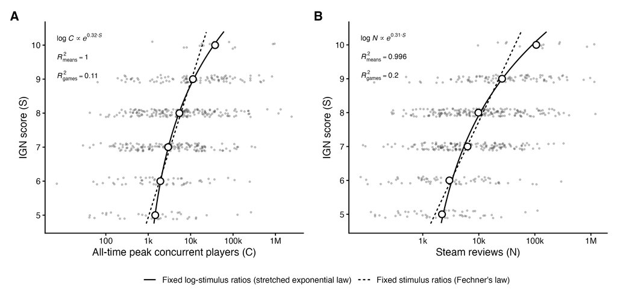

Figure 4: IGN ratings 5–10 against the two independent stimulus measures: all-time peak concurrent players (A, n = 508) and Steam total reviews (B, N = 560). The SE β is nearly identical across the two measures (0.32 vs 0.31). The zero-offset SE variant degenerates — the additive floor c₀ is essential. Generated by script 19.

### Functional-form race

NLS/OLS fits of log peak players on rating, ratings 5–10, n = 508 (from `73_form_comparison.csv`; lower AIC = better, AIC = Akaike information criterion, a fit measure penalized for parameter count):

```r
read.csv(file.path(pd, "73_form_comparison.csv")) |>
  mutate(AIC = round(AIC, 1), r2_raw = round(r2_raw, 3), r2_cat = round(r2_cat, 3)) |>
  kable(col.names = c("Model", "Params", "AIC", "R² (games)", "R² (category means)"))
```

| Model | Params | AIC | R² (games) | R² (category means) |
| --- | --- | --- | --- | --- |
| stretched-exp: logC = c + A·exp(beta·score) | 4 | 2168.8 | 0.107 | 0.999 |
| quadratic | 3 | 2168.8 | 0.107 | 0.996 |
| GAM s(score) | NA | 2170.1 | 0.106 | 0.971 |
| exponential (linear in log C) | 2 | 2170.1 | 0.101 | 0.915 |
| power law (log C ~ log score) | 2 | 2173.5 | 0.095 | 0.843 |

Table 4: Mean-function race on the primary measure, ratings 5–10 (73_form_comparison.csv): AIC, observation-level R², and category-mean R² per model.

The stretched exponential is AIC-best, and on the category means the ordering is unambiguous: SE 0.999, quadratic 0.996, constant-ratio exponential 0.915, power law 0.843. The same race on the review-based samples replicates (SE best over the exponential by ΔAIC ≈ 4 Steam / ≈ 19 console-inclusive, over the power law by ≈ 11 / ≈ 29; `16_comparison.csv`). The reason the power law dies is visible in the predicted step ratios (from `73_step_ratios.csv`): observed ratios rise from 1.32 to 3.33, the exponential holds them constant at 1.78, and the power law makes them *fall*:

```r
read.csv(file.path(pd, "73_step_ratios.csv")) |>
  mutate(across(where(is.numeric), \(x) round(x, 2))) |>
  kable(col.names = c("Step", "Observed", "Exponential", "Power law", "Quadratic", "SE"))
```

| Step | Observed | Exponential | Power law | Quadratic | SE |
| --- | --- | --- | --- | --- | --- |
| 5 → 6 | 1.32 | 1.78 | 2.07 | 1.27 | 1.35 |
| 6 → 7 | 1.53 | 1.78 | 1.85 | 1.53 | 1.52 |
| 7 → 8 | 1.84 | 1.78 | 1.71 | 1.84 | 1.78 |
| 8 → 9 | 2.09 | 1.78 | 1.60 | 2.21 | 2.22 |
| 9 → 10 | 3.33 | 1.78 | 1.52 | 2.66 | 3.00 |

Table 5: Observed per-step player-count ratios vs each model’s predicted step ratios (73_step_ratios.csv).

The SE β is identified only up to the log base of the score = log ψ reading (see `13_results.json` note); the threshold-based estimate ln r ≈ 0.22 is the base-e value for the primary sample (β̂ = 0.32 from the NLS mean function).

### Category means are almost exactly SE

Game-level noise is large (game-level R² ≈ 0.11 on players, ≈ 0.20 on reviews), but the **category means** are captured almost perfectly. On the primary measure the SE explains **99.9%** of the category-mean variance vs 91.5% for the constant-ratio model (`73_results.json`); the review-based samples replicate (from `17_item_level.csv`):

```r
read.csv(file.path(pd, "17_item_level.csv")) |>
  filter(sample %in% c("steam_5to10", "full_5to10")) |>
  transmute(Sample = ifelse(sample == "steam_5to10", "Steam (N = 560)",
                            "Console-inclusive (N = 803)"),
            `k categories` = k_items,
            `R² linear` = round(r2_linear, 3), `R² SE` = round(r2_se, 3)) |>
  kable()
```

| Sample | k categories | R² linear | R² SE |
| --- | --- | --- | --- |
| Steam (N = 560) | 6 | 0.946 | 0.996 |
| Console-inclusive (N = 803) | 6 | 0.883 | 0.996 |

Table 6: Category-mean R² for the linear (constant-ratio) vs stretched-exponential mean functions, ratings 5–10 (17_item_level.csv).

The SE curve explains **99.6%** of the variance in category-mean log stimulus in both samples, vs 94.6% / 88.3% for the linear (constant-ratio) model.

### Not a reviewing artifact

The primary measure settles the obvious confound by construction: peak concurrent players contains no review-writing anywhere in its pipeline, so “higher ratings just attract more *reviewing*” cannot produce its acceleration. For the secondary, review-count measure, two further checks say the same:

- **Decomposition** (script 17, SteamSpy owner brackets): β_reviews 0.594 = β_owners 0.532 (90%) + β_rate 0.062 (10%); the acceleration (quadratic term) sits in *owners* (p = .008), not in reviews-per-owner (p = .83).
- **Elasticity** (script 18): dev-reported sales scale as reviews^1.087 — the propensity-confound direction (b < 1) is contradicted.

## Supplement: thresholds and the graded response model

The mean-function evidence above is the page’s spine; this section is the psychometric supplement that reads the same structure off the **thresholds**.

### The model

Treat the rating as a graded item in the sense of item response theory: the **graded response model** (GRM — the standard psychometric model for ordered categories, and the workhorse of modern test scoring) places a set of ordered thresholds on an underlying continuum, and a response lands in category k when the underlying value falls between thresholds k−1 and k, up to Gaussian judgment noise. Anchoring the underlying continuum to **log stimulus** puts the thresholds in log-stimulus units, and the object of interest is the **spacing between successive thresholds** — the category widths. Scripts: `08_probit_thresholds.R`, `11_range_frequency.R`, `13_se_grm.R`, `16_upper_scale.R`, `22_theory_tests.R`, `73_ccu_primary.R`.

Threshold-spacing constraints compared, by AIC:

- **equidistant** — equal widths in log stimulus (the Fechnerian reading; 3 params),
- **geometric** — widths grow by a constant ratio r per step (4 params),
- **quantile / equal-mass** — thresholds at the stimulus quantiles matching category frequencies,
- **free** — every threshold estimated separately.

### Anchor space: log beats raw

The categorization is linear in **log** stimulus, not raw stimulus: on the primary measure, anchoring the free-threshold model on log players beats raw players by ΔAIC = 42.8 (script 73); on reviews, log beats raw by ΔAIC = 78.5 (script 08).

### Boundaries and widths

```r
w <- read.csv(file.path(pd, "73_boundaries.csv"))
w |> transmute(`Boundary` = boundary,
               `Boundary (log players)` = round(logC, 2),
               `Boundary (raw players)` = format(round(players), big.mark = ","),
               `Width below boundary (log-player units)` = round(width_logC, 2)) |>
  kable()
```

| Boundary | Boundary (log players) | Boundary (raw players) | Width below boundary (log-player units) |
| --- | --- | --- | --- |
| 5\|6 | -0.94 | 0 | NA |
| 6\|7 | 2.39 | 11 | 3.33 |
| 7\|8 | 7.75 | 2,326 | 5.36 |
| 8\|9 | 13.62 | 825,626 | 5.87 |
| 9\|10 | 20.94 | 1,243,077,167 | 7.32 |

Table 7: Freely estimated GRM thresholds on the primary measure: locations in log-player and raw-player units, and the implied category widths (73_boundaries.csv, ratings 5–10, n = 508).

Equidistant widths are rejected on the primary measure: likelihood-ratio χ² = 27.5, df = 3, p = 4.5 × 10⁻⁶ (script 73; the review-based tests agree — χ² = 33.5, p = 2.5 × 10⁻⁷ Steam and χ² = 36.2, p = 6.9 × 10⁻⁸ console-inclusive, script 16). Widths grow from 3.3 to 7.3 log-player units, and the top boundary extrapolates absurdly past the observed range: the 9|10 boundary sits at ≈ 1.2 **billion** simultaneous players — no observed stimulus level guarantees a 10.

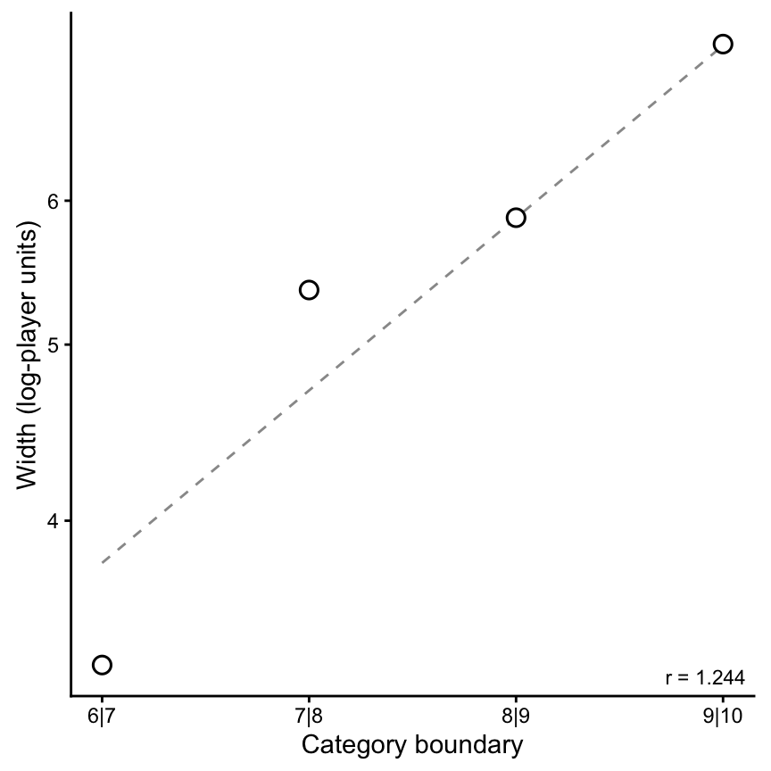

Figure 5: Category widths in log-player units, ratings 5–10 (open circles; 73_boundaries.csv). Log y-axis, where a geometric progression of widths is a straight line; the dashed reference has the tournament slope r = 1.244, centered on the observed widths.

```r
wp <- w |> filter(is.finite(width_logC))
wp$idx <- seq_len(nrow(wp))
r_hat <- r73$geometric_r
ref <- tibble::tibble(idx = wp$idx,
  width = exp(mean(log(wp$width_logC)) + log(r_hat) * (wp$idx - mean(wp$idx))))
ggplot(wp, aes(idx, width_logC)) +
  geom_line(data = ref, aes(idx, width), linetype = "dashed", color = "gray60") +
  geom_point(shape = 21, fill = "white", stroke = 0.8, size = 3) +
  scale_y_log10(breaks = c(3, 4, 5, 6, 8)) +
  scale_x_continuous(breaks = wp$idx, labels = wp$boundary) +
  annotate("text", x = Inf, y = min(wp$width_logC), hjust = 1.1, vjust = 1.3,
           size = 3, label = paste0("r = ", round(r_hat, 3))) +
  labs(x = "Category boundary", y = "Width (log-player units)") +
  theme_classic(base_size = 11) + theme(aspect.ratio = 1)
```

### The threshold tournament

```r
read.csv(file.path(pd, "73_threshold_models.csv")) |>
  mutate(AIC = round(AIC, 1)) |>
  kable(col.names = c("Threshold family", "Params", "AIC"))
```

| Threshold family | Params | AIC |
| --- | --- | --- |
| geometric widths | 4 | 1528.2 |
| flexible (polr) | 6 | 1529.1 |
| equidistant | 3 | 1550.6 |

Table 8: Threshold-family tournament on the primary measure, ratings 5–10 (73_threshold_models.csv): AIC per family.

**Geometric widths win outright**: r = 1.244, beating even the fully flexible model on AIC despite the flexible model’s extra parameters, with equidistant spacing 22.4 AIC behind. The review-based samples replicate: geometric wins outright there too, r = 1.269 (Steam) and r = 1.234 (console-inclusive; script 16), and on the full nine-score data the tournament additionally rejects quantile/equal-mass spacing by ΔAIC > 1000 (script 11).

### Range, not frequency

Two results against a frequency/rank reading (Parducci’s (1965) frequency principle; the rank/CDF anchor is the efficient-coding reading of Bhui & Gershman (2018); script 11):

- The **rank anchor loses to log magnitude**, AIC 1837.7 vs 1827.3, and adds nothing on top of it (1828.0).
- Category use is wildly non-uniform (observed shares vs uniform: χ² p ≈ 10⁻¹¹⁹) — raters do not equalize category frequencies.

The Parducci range weight pins at the boundary (w = 1.0), but range and frequency predictions correlate 0.98 here, so w is not separately identified; the anchor AIC comparison carries the conclusion.

### GRM readings

A graded response model (GRM — the standard item-response-theory model for ordered categories) fit two ways (script 13): frequencies-only (latent trait θ ~ N(0,1); thresholds are normal quantiles of the cumulative category shares) and anchored (θ = standardized log stimulus — the model used throughout this section).

```r
r13 <- read_json(file.path(pd, "13_results.json"))
tibble::tibble(
  Reading = c("Frequencies-only (θ ~ N(0,1))", "Anchored (θ = std log N)"),
  `Geometric ratio of threshold spacings` =
    c(r13$grm_freq_geo_ratio, r13$grm_anchored_geo_ratio)
) |> kable()
```

| Reading | Geometric ratio of threshold spacings |
| --- | --- |
| Frequencies-only (θ ~ N(0,1)) | 1.2694 |
| Anchored (θ = std log N) | 1.2766 |

Table 9: Geometric ratio of GRM threshold spacings under the frequencies-only vs anchored readings (13_results.json).

The two sets of thresholds correlate 1 — the geometric spacing is invariant to anchoring, because log stimulus is approximately normal over the reviewed set.

### Head-to-head threshold-model likelihood race

Script 22 races full threshold *theories* (not just families) on IGN 5–10 and on the stellar data of Section 6:

```r
read.csv(file.path(pd, "22_probit_race.csv")) |>
  mutate(AIC = round(AIC, 1), shape = round(shape, 3)) |>
  kable(col.names = c("Dataset", "Model", "Params", "AIC", "Shape param"))
```

| Dataset | Model | Params | AIC | Shape param |
| --- | --- | --- | --- | --- |
| IGN 5-10 | P1 Fechner/equidistant | 3 | 1674.5 | NA |
| IGN 5-10 | P2 exact-SE/geometric | 4 | 1644.1 | 1.269 |
| IGN 5-10 | P3 log-power/equidistant | 4 | 1676.3 | 1.167 |
| IGN 5-10 | P4 flexible | 7 | 1647.0 | NA |
| Stellar | P1 Fechner/equidistant | 3 | 19768.5 | NA |
| Stellar | P2 exact-SE/geometric | 4 | 19337.5 | 1.236 |
| Stellar | P3 log-power/equidistant | 4 | 19683.1 | 0.695 |
| Stellar | P4 flexible | 7 | 19285.1 | NA |

Table 10: Likelihood race across threshold theories, IGN 5–10 and stellar magnitudes (22_probit_race.csv).

The exact-SE/geometric model wins against its 4-parameter rivals in both datasets. A free-offset log-power model converges to the exact-SE solution as its exponent α → 0 (the Box–Cox limit); the data sit at or near that small-α corner *with* an additive floor — the floor is essential (the zero-offset refit degenerates).

## Stellar magnitudes

### Data

Historical stellar brightness catalogs in the Hipparchus tradition: 14 observers from Ptolemy (137 AD) through al-Sufi (964), Tycho Brahe (1598), Hevelius (1690), Flamsteed (1725), to Piazzi (1814), each assigning stars to magnitude classes 1 (brightest) – 6 (faintest). All 14 predate photometry — no instrument ever *measured* the brightness; every magnitude is a human eye’s category judgment. The late catalogs (Flamsteed onward, including Lacaille 1751 and Piazzi 1814) were observed *through* telescopes — the eye still judged, but with optical gain and, by then, a heavily codified scale convention. Each historical class assignment is paired with the star’s modern flux from Hipparcos V-band photometry. Data are loaded read-only from the paper’s final repository, `how_not_to_measure_repository` (its script `scripts/01_stars.R`, evaluated up to data construction only; nothing in that repository is ever modified). Scripts here: `20_stellar_reanalysis.R`, `69–71`.

Mapping to the IGN battery: S = 7 − magnitude class (so higher S = brighter, like higher IGN = better), x = log relative flux (relative to the class-6 mean). Fractional/intermediate class assignments are excluded.

**The analysis sample is the pre-telescope sky.** The 14 observers split into seven **pre-telescopic** (Ptolemy 137, al-Sufi 964, Wilhelm IV 1586, Tycho 1598, de Houtman 1603, Kepler 1627, Hevelius 1690 — all data collected before or without the telescope) and seven **telescopic-era** (Halley 1679 onward, whose positions came through optics while brightness was still judged by eye). Hevelius is the deliberate case: he worked decades into the telescope era and used telescopes for lunar and solar work, but refused telescopic sights for star measurements, arguing plain sights were just as accurate — the famous dispute with Hooke, which Halley’s 1679 visit to Danzig was sent to settle (and largely settled in Hevelius’s favor). His catalog is naked-eye by conviction, not by date. Telescopic depth is a real contaminant: it lets an observer put stars in class 6 (“faintest”) that are strictly fainter than anything a naked-eye observer ever rated — 52% of Lacaille’s stars appear in no other catalog, and unique stars are always the faint ones (script 71’s census). The raw catalogs also show the observers *knew* this: Flamsteed’s file contains classes 7–8 and Piazzi’s runs to 11 (all filtered out upstream by the ≤ 6 gate), while Lacaille’s catalog stops at 6 and lumps his telescope-only stars into it. The sample used on this page therefore keeps every pre-telescopic row and admits telescopic-era rows **only for stars present in at least one pre-telescopic catalog**: **N = 8,446** integer class assignments (3,452 telescopic-era rows on post-telescope-only stars dropped). Alternative cuts — none of which change the conclusion — are in Section 6.6.

### Per-class flux ratios accelerate — just like IGN

```r
pc <- read.csv(file.path(pd, "71_per_class_preera.csv"))
pc |> mutate(ror = flux_ratio_vs_prev / lag(flux_ratio_vs_prev)) |>
  transmute(`S (7 − class)` = S, n,
            `Mean log relative flux` = round(m, 2),
            `Ratio` = ifelse(is.na(flux_ratio_vs_prev), "—",
                             sprintf("%.2f", flux_ratio_vs_prev)),
            `Ratio ×` = ifelse(is.na(ror), "—", sprintf("%.2f", ror))) |>
  kable(align = "rrrrr")
```

| S (7 − class) | n | Mean log relative flux | Ratio | Ratio × |
| --- | --- | --- | --- | --- |
| 1 | 1756 | 0.00 | — | — |
| 2 | 2370 | 0.43 | 1.54 | — |
| 3 | 2549 | 0.96 | 1.70 | 1.10 |
| 4 | 1331 | 1.79 | 2.29 | 1.35 |
| 5 | 323 | 2.76 | 2.62 | 1.14 |
| 6 | 117 | 4.16 | 4.06 | 1.55 |

Table 11: Per-class counts, mean log relative flux, each class’s flux ratio over the class below (Ratio), and each ratio’s growth over the ratio below (Ratio ×) (71_per_class_preera.csv; the page’s stellar sample, N = 8,446).

The step ratios climb monotonically, ×1.54 → ×1.70 → ×2.29 → ×2.62 → **×4.06** at the top step — compare IGN’s top step of ×4.07. Written as a compounding chain (the Ratio × column): 1.54 → (×1.10) → 1.70 → (×1.35) → 2.29 → (×1.14) → 2.62 → (×1.55) → 4.06 — every multiplier itself multiplies, by a factor hovering around ~1.1–1.6 with no trend. Pogson’s 1856 standardization of the magnitude scale *assumed* a constant ratio (2.512× per class); the historical assignments the scale was built on do not have constant ratios. (Section 6.6 additionally splits the sample by era.)

This turns out to answer a question Stevens left open. Stevens and Galanter (1957, pp. 397–398) identified the stellar magnitude scale as the oldest category scale on record, noted that their own laboratory category scales for star-like points of light came out concave *upward* against decibels (categories narrowing toward the bright end), and asked whether the pre-photometric stellar catalogs were really linear in decibels or curved the same way — closing, after sampling Flamsteed and Herschel and finding the history hard going, with “Perhaps someone better qualified than we are should try to answer this question.” The answer, sixty-nine years on: not linear, and curved the *opposite* way from their laboratory spots. Against decibels the historical scale is concave **downward** — the per-class step grows from ≈ 1.9 dB at the faint end to ≈ 6.1 dB at the bright end, straddling Pogson’s uniform 4 dB — the same direction of acceleration as every other battery on this page.

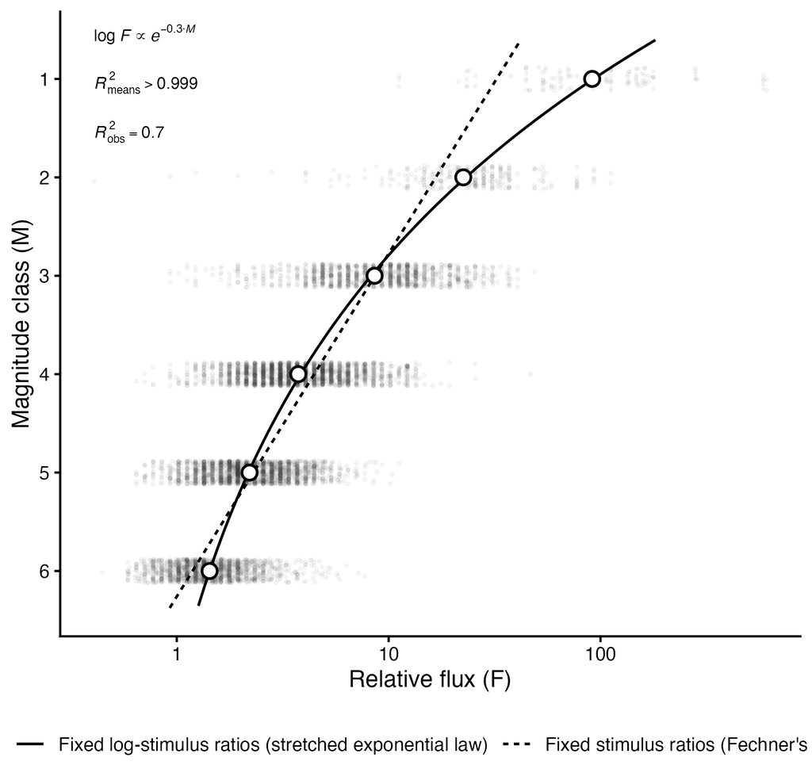

Figure 6: The stellar categorization in the same design as the IGN panels of Figure 1: magnitude class (1 = brightest, top) against relative flux (log x-axis), individual class assignments as gray dots, class geometric means as open circles, fixed log-stimulus ratios (solid; the SE law’s observable form) vs fixed stimulus ratios (dashed; Fechner’s law). Generated by script 21 (standalone preera panel).

### Mean-function race

Same battery as the IGN data (AIC for linear/constant-ratio, SE, quadratic, plus the power law in raw stimulus):

```r
mfu <- r71$preera$battery$mean_function
aicv <- unlist(mfu$aic)   # order: linear, se, quadratic, power_raw
tibble::tibble(
  Model = c("Fixed stimulus ratios (Fechner/Pogson)",
            "Fixed log-stimulus ratios (SE law)",
            "Quadratic", "Power law in raw stimulus"),
  AIC = round(aicv[c(1, 2, 3, 4)], 1)
) |> kable()
```

| Model | AIC |
| --- | --- |
| Fixed stimulus ratios (Fechner/Pogson) | 14008.9 |
| Fixed log-stimulus ratios (SE law) | 13006.7 |
| Quadratic | 13019.9 |
| Power law in raw stimulus | 16451.0 |

Table 12: Stellar mean-function race on the page’s sample (71_results.json, preera battery, N = 8,446): AIC per model.

The SE wins (β = 0.297 — nearly identical to IGN’s 0.31), the quadratic is close behind, the linear model trails by ~1,000 AIC, and the raw-stimulus power law is not in the race (~3,400 AIC behind the SE). Class-mean R²: linear 0.899 vs SE 0.9997 — the same near-perfect category-mean fit as IGN.

### Thresholds

```r
thu <- r71$preera$battery$thresholds$pooled
tibble::tibble(
  Family = c("Flexible", "Geometric", "Equidistant"),
  AIC = round(c(thu$flex_aic, thu$geom$aic, thu$equi$aic), 1)
) |> kable()
```

| Family | AIC |
| --- | --- |
| Flexible | 16708.7 |
| Geometric | 16744.1 |
| Equidistant | 16969.1 |

Table 13: Stellar threshold-family tournament on the page’s sample (71_results.json, preera battery): AIC per family.

Equidistant spacing is rejected (ΔAIC = 225 vs geometric). The geometric ratio is **r = 1.173** — in the same band as IGN’s 1.24–1.27. The flexible family beats geometric by 35 AIC — with n ≈ 8k the data can afford 3 extra parameters; the geometric ratio remains the summary of how the widths grow.

### Per-observer stability

SE β fit separately per observer (observers with ≥ 500 assignments and enough classes; from `20_per_observer.csv`):

```r
read.csv(file.path(pd, "20_per_observer.csv")) |>
  filter(is.finite(se_beta)) |>
  transmute(Observer = observer, n, `SE β` = round(se_beta, 2)) |>
  arrange(desc(`SE β`)) |>
  kable()
```

| Observer | n | SE β |
| --- | --- | --- |
| Tycho Brahe (1598) | 954 | 0.35 |
| Ptolemy (137) | 1005 | 0.30 |
| Hevelius (1690) | 1490 | 0.29 |
| al-Sufi (964) | 1005 | 0.28 |
| Flamsteed (1725) | 2160 | 0.17 |

Table 14: Per-observer stretched-exponential β (20_per_observer.csv).

Ptolemy (137 AD) and al-Sufi (964) land within a few hundredths of each other and of the IGN Steam-sample β = 0.31 — the acceleration is not an artifact of one observer or era.

### Pre- vs post-telescope

The sample keeps the stars comparable across eras, but the two observer groups may still sit at different levels or behave differently. Two checks (script 71): a threshold model with a single **era effect** — one location shift for the telescopic-era observers, thresholds shared — and the battery run **separately per era** on this sample.

```r
r70 <- read_json(file.path(pd, "70_results.json"))
tu <- r71$preera$battery$thresholds
tibble::tibble(
  `Threshold family` = c("Equidistant", "Geometric", "Flexible"),
  `AIC, pooled` = round(c(tu$pooled$equi$aic, tu$pooled$geom$aic, tu$pooled$flex_aic), 1),
  `AIC, era shift` = round(c(tu$era$equi$aic, tu$era$geom$aic, tu$era$flex_aic), 1)
) |> kable()
```

| Threshold family | AIC, pooled | AIC, era shift |
| --- | --- | --- |
| Equidistant | 16969.1 | 16383.1 |
| Geometric | 16744.1 | 16195.7 |
| Flexible | 16708.7 | 16160.8 |

Table 15: Threshold-family AICs for the stellar categorization on the page’s sample, pooled vs with a pre/post-telescope era shift (71_results.json, preera battery; N = 8,446). Lower is better.

Results, stated plainly:

- **The acceleration survives the era control.** Equidistant spacing is rejected with the era shift in the model (ΔAIC = 187 vs geometric), and the geometric ratio barely moves: r = 1.173 pooled vs **r = 1.155** with the shift (the fitted post-telescope offset is -0.63 in judgment-noise units).
- **The two eras, analyzed separately**: the seven pre-telescopic observers alone give **r = 1.179** (n = 5,517, ΔAIC vs equidistant = 168); the seven telescopic-era observers, restricted to pre-telescope-era stars, give **r = 1.081** (n = 2,929, ΔAIC = 14) — the convention-era raters are much closer to log-linear, but even they never favor equidistant spacing.
- **Recode instead of exclude**: assigning the telescopic-era observers’ post-telescope-only class-6 stars to a **class 7** — historically defensible, since Galileo proposed a seventh magnitude and Flamsteed’s and Piazzi’s own catalogs contain classes 7–8 and 7–11 respectively (entries the ≤ 6 gate upstream removes), while Lacaille’s catalog lumps everything faint into 6 — keeps all 11,898 rows (3,158 recoded), and the K = 7 battery gives **r = 1.303** with ΔAIC = 1,490 over equidistant: the seventh category extends the geometric ladder downward and the widths keep compounding.
- **Robustness across all sample choices**: raw 14-catalog pool r = 1.235 (1.163 with per-observer fixed effects, script 70); unique-star class-6 exclusion only, r = 1.187 (1.144 FE); dropping Lacaille and Piazzi entirely, r = 1.206 (1.166 FE); strict four-observer naked-eye core, r = 1.185 (FE). Every variant rejects equidistant spacing.
- **Observers differ in how curved they are.** Per-observer geometric r, fit on each observer’s full catalog (script 70; observers with ≥ 500 assignments; ΔAIC > 0 favors geometric over equidistant):

```r
read.csv(file.path(pd, "70_per_observer_r.csv")) |>
  arrange(desc(r)) |>
  transmute(Observer = observer, n, r = round(r, 3),
            `ΔAIC (equidistant − geometric)` = round(d_aic, 1)) |>
  kable()
```

| Observer | n | r | ΔAIC (equidistant − geometric) |
| --- | --- | --- | --- |
| Tycho Brahe (1598) | 954 | 1.265 | 54.6 |
| Flamsteed (1725) | 2160 | 1.178 | 25.0 |
| Hevelius (1690) | 1490 | 1.168 | 30.6 |
| al-Sufi (964) | 1005 | 1.129 | 17.4 |
| Ptolemy (137) | 1005 | 1.066 | 2.6 |
| Lacaille (1751) | 1808 | 1.063 | -0.2 |
| Piazzi (1814) | 1882 | 1.034 | -1.0 |

Table 16: Per-observer geometric ratio r and its AIC advantage over equidistant spacing (70_per_observer_r.csv).

Tycho, Flamsteed, Hevelius, and al-Sufi are clearly geometric (ΔAIC +17 to +55); Ptolemy weakly so; the two most recent observers — Lacaille (1751) and Piazzi (1814), who judged brightness by eye through telescopes while conforming to a by-then heavily codified scale convention — are indistinguishable from log-linear on their full catalogs (r ≈ 1.03–1.06, ΔAIC ≈ 0). Their flatness stays in their own panels (script 70’s per-observer figure, `figures/70_stellar_by_observer.png`); per the robustness bullet above, no sample choice involving them changes the shared conclusion.

## Word familiarity × word frequency

### Data

**Rating**: word familiarity (FAM) from the Glasgow Norms (Scott et al. 2019) — 1–7 scale, item means over ~30 raters, rounded to integers here (an *aggregate* battery: the unit is the word, not the individual rater response). **Stimulus (anchor)**: SUBTLEX-UK Zipf frequency (van Heuven et al. 2014) — Zipf = log₁₀ occurrences per billion words, already a log-scale quantity, from a British subtitle corpus matching the British raters. Words joined on lowercase spelling, parenthetical sense markers stripped; join n = 4,677 words. Scripts: `58_norms.R`, `60_glasgow_cd.R` (battery: `24_battery.R`, validated by simulation in script 25 — the estimator recovers r = 1 on null data and r = 1.24 without bias across category counts and stimulus distributions).

### Same battery, same pattern

```r
g <- bind_rows(read.csv(file.path(pd, "58_norms.csv"))[1, ],
               read.csv(file.path(pd, "60_glasgow_cd.csv")))
g |> transmute(
  Battery = label, n, K,
  `Geometric r` = round(r_geom, 3),
  `ΔAIC equidistant − geometric` = round(d_aic_equi_minus_geom, 0),
  `SE β` = round(se_beta, 3),
  `R² category means (SE)` = round(r2_cat_se, 3),
  `R² category means (linear)` = round(r2_cat_lin, 3)
) |> kable()
```

| Battery | n | K | Geometric r | ΔAIC equidistant − geometric | SE β | R² category means (SE) | R² category means (linear) |
| --- | --- | --- | --- | --- | --- | --- | --- |
| Word familiarity (Glasgow FAM, rounded item mean) × SUBTLEX-UK Zipf | 4677 | 6 | 1.409 | 450 | 0.210 | 0.998 | 0.986 |
| Word familiarity (Glasgow FAM) × contextual diversity (BBC programs) | 4677 | 6 | 1.389 | 424 | 0.148 | 0.998 | 0.992 |

Table 17: Glasgow familiarity batteries (58_norms.csv, 60_glasgow_cd.csv): geometric r, equidistant-vs-geometric ΔAIC, SE β, and category-mean R².

Words rated one FAM step apart differ in corpus frequency by a *growing* multiplicative factor: geometric widths with **r = 1.41**, beating equidistant spacing by ~450 AIC. The SE mean function again captures the category means almost perfectly (R² = 0.998 vs 0.986 linear). The result is robust to the stimulus choice: contextual diversity (the number of distinct BBC programs a word appears in, an alternative SUBTLEX-UK exposure measure) gives r = 1.39.

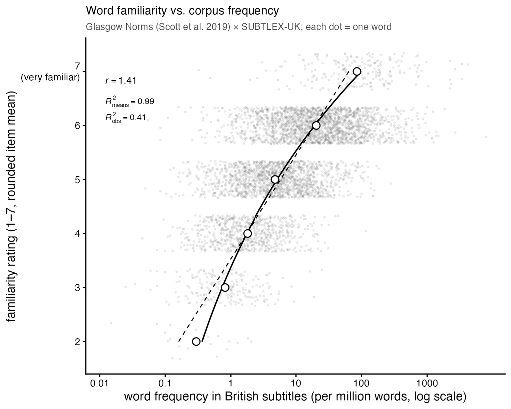

Figure 7: Glasgow familiarity × SUBTLEX-UK frequency: category geometric means with SE fit vs constant-ratio reference. Generated by script 59.

## Side by side

### The three domains in one table

```r
g58 <- read.csv(file.path(pd, "58_norms.csv"))[1, ]
g60 <- read.csv(file.path(pd, "60_glasgow_cd.csv"))

tibble::tribble(
  ~Battery, ~Rating, ~Anchor, ~n, ~K, ~r,
  "IGN × peak concurrent players", "IGN 5–10", "log all-time peak concurrent players",
    r73$n, 6, r73$geometric_r,
  "IGN × Steam reviews", "IGN 5–10", "log Steam total reviews",
    r16$steam$n, 6, r16$steam$geom_r,
  "IGN console-inclusive", "IGN 5–10", "log Metacritic user-rating count",
    r16$full$n, 6, r16$full$geom_r,
  "Stellar magnitudes", "class 1–6, 14 observers 137–1814 AD", "log relative flux (Hipparcos V)",
    r71$preera$battery$n, 6, r71$preera$battery$thresholds$pooled$geom$r,
  "Word familiarity", "Glasgow FAM 1–7 (item means)", "SUBTLEX-UK Zipf",
    g58$n, 6, g58$r_geom,
  "Word familiarity (robustness)", "Glasgow FAM 1–7 (item means)", "SUBTLEX-UK contextual diversity",
    g60$n, 6, g60$r_geom
) |>
  mutate(r = round(r, 3)) |>
  kable(col.names = c("Battery", "Rating scale", "Stimulus (anchor)", "n", "K categories",
                      "Geometric r"))
```

| Battery | Rating scale | Stimulus (anchor) | n | K categories | Geometric r |
| --- | --- | --- | --- | --- | --- |
| IGN × peak concurrent players | IGN 5–10 | log all-time peak concurrent players | 508 | 6 | 1.244 |
| IGN × Steam reviews | IGN 5–10 | log Steam total reviews | 560 | 6 | 1.269 |
| IGN console-inclusive | IGN 5–10 | log Metacritic user-rating count | 803 | 6 | 1.234 |
| Stellar magnitudes | class 1–6, 14 observers 137–1814 AD | log relative flux (Hipparcos V) | 8446 | 6 | 1.173 |
| Word familiarity | Glasgow FAM 1–7 (item means) | SUBTLEX-UK Zipf | 4677 | 6 | 1.409 |
| Word familiarity (robustness) | Glasgow FAM 1–7 (item means) | SUBTLEX-UK contextual diversity | 4677 | 6 | 1.389 |

Table 18: All six batteries: rating scale, stimulus anchor, sample size, category count, and geometric ratio r.

### Standing caveats

- The IGN stimulus measures (review counts, user-rating counts, concurrent players) are outcome proxies for the judged magnitude, not unit sales and not quantities any reviewer observed; all IGN relations are correlational.
- The word-familiarity batteries are **aggregate-level** (item means over raters), not individual responses.
- The stellar sample is the pre-telescope sky: telescopic-era rows enter only for stars in ≥ 1 pre-telescopic catalog (3,452 rows dropped; Section 6). Across sample choices the headline ratio runs 1.081–1.303 (separate telescopic-era group at the bottom, class-7 recode at the top; page sample 1.173, era-controlled 1.155, raw pool 1.235) — equidistant is rejected in every variant. Per-observer r runs 1.03–1.27, all ≥ 1, with the two latest observers ≈ log-linear on their full catalogs.

## References

- Bhui, R., & Gershman, S. J. (2018). Decision by sampling implements efficient encoding of psychoeconomic functions. *Psychological Review*, 125(6), 985–1001.
- Chituc, V., & Santos, L. R. (under review). How (not) to measure subjective experience. Manuscript under review.
- Fechner, G. T. (1860). *Elemente der Psychophysik*. Leipzig: Breitkopf & Härtel.
- Kohlrausch, R. (1854). Theorie des elektrischen Rückstandes in der Leidener Flasche. *Annalen der Physik und Chemie* (Poggendorff), 91, 179–214.
- Laherrère, J., & Sornette, D. (1998). Stretched exponential distributions in nature and economy: “fat tails” with characteristic scales. *The European Physical Journal B*, 2, 525–539.
- Luce, R. D., & Edwards, W. (1958). The derivation of subjective scales from just noticeable differences. *Psychological Review*, 65(4), 222–237.
- Meehl, P. E. (1990). Appraising and amending theories: The strategy of Lakatosian defense and two principles that warrant it. *Psychological Inquiry*, 1(2), 108–141.
- Parducci, A. (1965). Category judgment: A range-frequency model. *Psychological Review*, 72(6), 407–418.
- Pednekar, D., Krishnadas, A., Cho, B., & Makris, N. C. (2023). Weber’s Law of perception is a consequence of resolving the intensity of natural scintillating light and sound with the least possible error. *Proceedings of the Royal Society A*, 479, 20220626.
- Pogson, N. (1856). Magnitudes of thirty-six of the minor planets for the first day of each month of the year 1857. *Monthly Notices of the Royal Astronomical Society*, 17, 12–15.
- Poulton, E. C. (1968). The new psychophysics: Six models for magnitude estimation. *Psychological Bulletin*, 69(1), 1–19.
- Salmon, W. C. (1984). *Scientific Explanation and the Causal Structure of the World*. Princeton, NJ: Princeton University Press.
- Scott, G. G., Keitel, A., Becirspahic, M., Yao, B., & Sereno, S. C. (2019). The Glasgow Norms: Ratings of 5,500 words on nine scales. *Behavior Research Methods*, 51(3), 1258–1270.
- Shepard, R. N. (1981). Psychological relations and psychophysical scales: On the status of “direct” psychophysical measurement. *Journal of Mathematical Psychology*, 24(1), 21–57.
- Stevens, S. S. (1957). On the psychophysical law. *Psychological Review*, 64(3), 153–181.
- Stevens, S. S., & Galanter, E. H. (1957). Ratio scales and category scales for a dozen perceptual continua. *Journal of Experimental Psychology*, 54(6), 377–411.
- Teghtsoonian, R. (1973). Range effects in psychophysical scaling and a revision of Stevens’ law. *The American Journal of Psychology*, 86(1), 3–27.
- Thurstone, L. L. (1927). A law of comparative judgment. *Psychological Review*, 34(4), 273–286.
- van Heuven, W. J. B., Mandera, P., Keuleers, E., & Brysbaert, M. (2014). SUBTLEX-UK: A new and improved word frequency database for British English. *Quarterly Journal of Experimental Psychology*, 67(6), 1176–1190.